# Projet : Détection d'anomalies dans les indices boursiers par Victor Parcigneau et Suzelie Logel Demoulin

Contexte et Objectifs : Dans un environnement financier globalisé, les indices boursiers sont des indicateurs essentiels de la santé économique et des tendances des marchés. Les anomalies dans ces indices peuvent indiquer des événements significatifs tels que des crises financières, des changements économiques majeurs ou des manipulations de marché. La détection proactive de ces anomalies est cruciale pour les investisseurs, les régulateurs et les analystes financiers afin de prendre des décisions éclairées et de minimiser les risques.

Le projet que nous avons entrepris vise à développer un système automatisé capable de détecter des anomalies dans les données des indices boursiers à l'aide de techniques avancées de data science et d'apprentissage automatique.

Collecte et Préparation des Données Nous avons utilisé l'API de yfinance pour télécharger les données historiques des principaux indices boursiers mondiaux tels que CAC 40, Dow Jones, S&P 500, NASDAQ Composite, DAX, Nikkei 225, Hang Seng Index, FTSE 100, BSE Sensex et S&P/ASX 200. Les données téléchargées comprennent les prix d'ouverture, de clôture, le plus haut et le plus bas de chaque journée de bourse ainsi que les ajustements de clôture.

```python
!pip install yfinance
!pip install schedule
```

[output not shown]

Transformation des Données, préparation de données. 1. Création de fonctions supplémentaires Pour enrichir les données boursières initiales, nous avons ajouté trois nouvelles colonnes : - Open-Close : Cette colonne calcule la différence entre le prix de clôture (`Close`) et le prix d'ouverture (`Open`) pour chaque journée. Cela aide à capturer les variations intra-journalières des indices, fournissant des indications sur les tendances haussières ou baissières au sein de chaque journée. - Return : La colonne `Return` mesure le rendement quotidien, défini comme le rapport du prix de clôture sur le prix d'ouverture moins un. Cette mesure est cruciale pour évaluer la performance quotidienne des indices et comprendre les gains ou pertes journaliers. - Volatility : Pour mesurer la volatilité, nous avons calculé l'écart-type des rendements quotidiens sur une période de 7 jours. La volatilité indique la stabilité ou l'instabilité des indices sur une semaine, ce qui est essentiel pour évaluer le risque. 2. Nettoyage des données Nous avons effectué plusieurs opérations pour nettoyer les données : - Suppression des colonnes non pertinentes : La colonne `Volume` a été supprimée car elle faussait notre IA qui ne prenait en compte que cette donnée, ce qui entraînait une détection erronée des anomalies après 2017. C'est à ce moment que le trading automatisé a explosé, entraînant une augmentation soudaine et massive des volumes échangés, similaire à ce qui a été observé lors des crises de 2008 et 2001. - Gestion des valeurs manquantes : Les lignes contenant des valeurs manquantes dans les colonnes essentielles (Open, High, Low, Close, Adj Close, Open-Close, Return, Volatility) ont été supprimées pour assurer la complétude et la fiabilité des données. - Réinitialisation de l'index : Après la suppression des lignes avec des valeurs manquantes, nous avons réinitialisé l'index du DataFrame pour maintenir un index continu et cohérent. 3. Vérification des Données Pour garantir la qualité des données après transformation : - Absence de valeurs manquantes : Nous avons vérifié qu'il n'y avait plus de valeurs manquantes dans les colonnes essentielles pour éviter tout problème lors de l'analyse. - Absence de valeurs infinies : Nous avons vérifié qu'il n'y avait pas de valeurs infinies dans nos colonnes, ce qui pourrait perturber les modèles de machine learning. Ces transformations et vérifications ont permis de préparer un ensemble de données propre, complet et enrichi, prêt pour une analyse approfondie et l'application de modèles de machine learning sophistiqués pour la détection d'anomalies dans les indices boursiers. Ces étapes sont essentielles pour garantir la qualité et la fiabilité des résultats de notre projet.

```python
import yfinance as yf
import pandas as pd
import numpy as np

# Liste des symboles des indices qu'on souhaite télécharger
index_symbols = ['^FCHI', '^DJI', '^GSPC', '^IXIC', '^GDAXI', '^N225', '^HSI', '^FTSE', '^BSESN', '^AORD']

# Télécharger les données pour chaque indice
index_data_frames = {}
for symbol in index_symbols:
    index_data = yf.download(symbol, start="1970-01-01", end="2022-12-31")
    index_data.reset_index(inplace=True)  # Réinitialiser l'index
    index_data.rename(columns={'index': 'Date'}, inplace=True)  # Renommer la colonne index en 'Date'
    index_data_frames[symbol] = index_data

# Concaténer les données
data_frames = list(index_data_frames.values())
data = pd.concat(data_frames, ignore_index=True)

# Calculer la colonne Open-Close
data['Open-Close'] = data['Close'] - data['Open']

# Calculer la colonne Return
data['Return'] = (data['Close'] / data['Open'] - 1)

# Calculer la colonne Volatility (écart-type des returns sur une période de 7 jours)
data['Volatility'] = data['Return'].rolling(window=7).std()

cols = ['Open', 'High', 'Low', 'Close', 'Adj Close', 'Open-Close', 'Return', 'Volatility']

# Supprimer la colonne 'Volume'
data.drop(columns=['Volume'], inplace=True)

# Supprimer les valeurs manquantes
data.dropna(subset=cols, inplace=True)

# Réindexer le DataFrame
data.reset_index(drop=True, inplace=True)
# Vérifier qu'il n'y a plus de valeurs manquantes
print(data[cols].isnull().sum())  # Devrait afficher 0 pour chaque colonne

# Vérifier les valeurs infinies
print(np.isinf(data[cols]).sum())  # Devrait afficher 0 pour chaque colonne
```

```
[*********************100%%**********************]  1 of 1 completed
[*********************100%%**********************]  1 of 1 completed
[*********************100%%**********************]  1 of 1 completed
[*********************100%%**********************]  1 of 1 completed
[*********************100%%**********************]  1 of 1 completed
[*********************100%%**********************]  1 of 1 completed
[*********************100%%**********************]  1 of 1 completed
[*********************100%%**********************]  1 of 1 completed
[*********************100%%**********************]  1 of 1 completed
[*********************100%%**********************]  1 of 1 completed
```

```
Open          0
High          0
Low           0
Close         0
Adj Close     0
Open-Close    0
Return        0
Volatility    0
dtype: int64
Open          0
High          0
Low           0
Close         0
Adj Close     0
Open-Close    0
Return        0
Volatility    0
dtype: int64
```

Normalisation des Données & Réseaux de neurones La normalisation est une étape essentielle dans le prétraitement des données, en particulier lorsque l'on utilise des modèles de machine learning. Elle permet de mettre toutes les variables sur une échelle commune, ce qui facilite l'apprentissage des modèles. En effet, des variables ayant des échelles très différentes peuvent perturber l'apprentissage des modèles de machine learning, car ces modèles peuvent attribuer une importance disproportionnée aux variables avec des valeurs plus grandes. Extraction des fonctionnalités : Nous avons commencé par extraire les valeurs des colonnes d'intérêt de notre ensemble de données. Cela permet de se concentrer uniquement sur les variables pertinentes pour l'analyse. Application de StandardScaler : Nous avons utilisé StandardScaler de la bibliothèque scikit-learn pour transformer les données. Cette méthode standardise les données en leur donnant une moyenne de zéro et un écart-type de un. Cela garantit que toutes les variables sont sur la même échelle, ce qui est crucial pour éviter que certaines variables dominent l'apprentissage du modèle en raison de leurs amplitudes plus élevées. Reshape des données : Avant de passer les données à notre modèle d'autoencodeur convolutionnel, nous les avons remodelées pour qu'elles aient la forme appropriée pour l'apprentissage profond. Les données sont transformées en une structure tridimensionnelle, où la troisième dimension est de taille 1, facilitant ainsi l'application des couches convolutives. Construction de l'Autoencodeur Convolutionnel Une fois les données normalisées, nous avons construit un autoencodeur convolutionnel. Ceux-ci sont des réseaux de neurones utilisés pour apprendre une représentation compacte des données et sont particulièrement efficaces pour la détection d'anomalies. Voici les étapes de la construction de notre modèle : Nous avons défini l'entrée du modèle en fonction du nombre de fonctionnalités après normalisation, ce qui permet de spécifier clairement la structure des données d'entrée. Puis nous avons ajouté des couches convolutives pour extraire les caractéristiques importantes des données et des couches de pooling pour réduire la dimensionnalité. Ces couches permettent au modèle de capturer les motifs locaux et de les combiner en caractéristiques plus abstraites. Les données convoluées sont aplaties avant d'être passées à une couche dense (fully connected) qui agit comme un encodeur. Cette étape compresse les données en une représentation de plus petite dimension, ce qui facilite l'identification des caractéristiques principales des données.Les données encodées sont ensuite passées par des couches de déconvoution et de upsampling pour reconstruire les données à leur forme originale. Ce processus inverse l'encodage pour tenter de reproduire les données d'entrée. Le modèle est compilé avec l'optimiseur adam et la fonction de perte mean_squared_error. Ensuite, nous avons entraîné le modèle sur les données normalisées. L'objectif est de minimiser l'erreur de reconstruction, ce qui permet au modèle d'apprendre à reconstruire les données d'entrée avec précision. La normalisation des données et la construction d'un autoencodeur convolutionnel sont des étapes essentielles pour garantir un apprentissage efficace et une détection précise des anomalies. En standardisant les données, en utilisant des couches convolutives pour extraire des caractéristiques importantes, et en minimisant l'erreur de reconstruction, nous assurons que notre modèle est bien adapté pour détecter les comportements anormaux dans les données. Cette approche permet de créer un système robuste et fiable pour la surveillance proactive des marchés financiers et autres applications.

```python
import numpy as np
import pandas as pd
from sklearn.preprocessing import StandardScaler
from tensorflow.keras.models import Model
from tensorflow.keras.layers import Input, Conv1D, MaxPooling1D, UpSampling1D, Flatten, Reshape, Dense

# Prétraiter les données
features = data[cols].values

# Normaliser les données
scaler = StandardScaler()
features_scaled = scaler.fit_transform(features)

# Définir l'architecture de l'autoencodeur convolutionnel
input_dim = features_scaled.shape[1]

# Remodeler les données pour l'autoencodeur
features_scaled = features_scaled.reshape(-1, input_dim, 1)

# Définir la dimension de l'encodage
encoding_dim = 16  # Vous pouvez ajuster cette dimension

# Définir l'architecture de l'autoencodeur avec des couches convolutives
input_layer = Input(shape=(input_dim, 1))
conv1 = Conv1D(filters=16, kernel_size=3, activation='relu', padding='same')(input_layer)
maxpool1 = MaxPooling1D(pool_size=2)(conv1)
conv2 = Conv1D(filters=8, kernel_size=3, activation='relu', padding='same')(maxpool1)
maxpool2 = MaxPooling1D(pool_size=2)(conv2)
flatten = Flatten()(maxpool2)
encoder = Dense(encoding_dim, activation="relu")(flatten)

# Calcul de reshape_dim pour la couche Reshape
reshape_dim = input_dim // 4 * 8

# Decoder
reshape = Reshape((reshape_dim // 8, 8))(encoder)
conv3 = Conv1D(filters=8, kernel_size=3, activation='relu', padding='same')(reshape)
upsample1 = UpSampling1D(size=2)(conv3)
conv4 = Conv1D(filters=16, kernel_size=3, activation='relu', padding='same')(upsample1)
upsample2 = UpSampling1D(size=2)(conv4)
decoder = Conv1D(filters=1, kernel_size=3, activation='sigmoid', padding='same')(upsample2)

autoencoder = Model(inputs=input_layer, outputs=decoder)
autoencoder.compile(optimizer='adam', loss='mean_squared_error')

# Entraîner l'autoencodeur
history = autoencoder.fit(features_scaled, features_scaled,
                          epochs=50,
                          batch_size=32,
                          shuffle=True,
                          validation_split=0.1)
```

```
2703/2703 ━━━━━━━━━━━━━━━━━━━━ 8s 2ms/step - loss: 0.7087 - val_loss: 0.2993
2703/2703 ━━━━━━━━━━━━━━━━━━━━ 7s 3ms/step - loss: 0.5983 - val_loss: 0.2987
2703/2703 ━━━━━━━━━━━━━━━━━━━━ 8s 3ms/step - loss: 0.6052 - val_loss: 0.2985
2703/2703 ━━━━━━━━━━━━━━━━━━━━ 8s 3ms/step - loss: 0.5998 - val_loss: 0.2983
2703/2703 ━━━━━━━━━━━━━━━━━━━━ 7s 2ms/step - loss: 0.6037 - val_loss: 0.2982
2703/2703 ━━━━━━━━━━━━━━━━━━━━ 7s 3ms/step - loss: 0.6131 - val_loss: 0.2982
2703/2703 ━━━━━━━━━━━━━━━━━━━━ 8s 3ms/step - loss: 0.5971 - val_loss: 0.2982
2703/2703 ━━━━━━━━━━━━━━━━━━━━ 7s 3ms/step - loss: 0.5983 - val_loss: 0.2981
2703/2703 ━━━━━━━━━━━━━━━━━━━━ 7s 2ms/step - loss: 0.6012 - val_loss: 0.2983
2703/2703 ━━━━━━━━━━━━━━━━━━━━ 6s 2ms/step - loss: 0.6081 - val_loss: 0.2981
2703/2703 ━━━━━━━━━━━━━━━━━━━━ 6s 2ms/step - loss: 0.5986 - val_loss: 0.2982
2703/2703 ━━━━━━━━━━━━━━━━━━━━ 7s 2ms/step - loss: 0.5995 - val_loss: 0.2982
2703/2703 ━━━━━━━━━━━━━━━━━━━━ 6s 2ms/step - loss: 0.6076 - val_loss: 0.2981
2703/2703 ━━━━━━━━━━━━━━━━━━━━ 7s 3ms/step - loss: 0.6015 - val_loss: 0.2982
2703/2703 ━━━━━━━━━━━━━━━━━━━━ 7s 3ms/step - loss: 0.5995 - val_loss: 0.2980
2703/2703 ━━━━━━━━━━━━━━━━━━━━ 7s 3ms/step - loss: 0.5964 - val_loss: 0.2981
2703/2703 ━━━━━━━━━━━━━━━━━━━━ 7s 3ms/step - loss: 0.6075 - val_loss: 0.2980
2703/2703 ━━━━━━━━━━━━━━━━━━━━ 7s 3ms/step - loss: 0.6026 - val_loss: 0.2980
2703/2703 ━━━━━━━━━━━━━━━━━━━━ 7s 2ms/step - loss: 0.6009 - val_loss: 0.2980
2703/2703 ━━━━━━━━━━━━━━━━━━━━ 7s 3ms/step - loss: 0.5976 - val_loss: 0.2980
2703/2703 ━━━━━━━━━━━━━━━━━━━━ 6s 2ms/step - loss: 0.6119 - val_loss: 0.2984
2703/2703 ━━━━━━━━━━━━━━━━━━━━ 6s 2ms/step - loss: 0.5959 - val_loss: 0.2981
2703/2703 ━━━━━━━━━━━━━━━━━━━━ 6s 2ms/step - loss: 0.5987 - val_loss: 0.2980
2703/2703 ━━━━━━━━━━━━━━━━━━━━ 6s 2ms/step - loss: 0.6065 - val_loss: 0.2981
2703/2703 ━━━━━━━━━━━━━━━━━━━━ 6s 2ms/step - loss: 0.5937 - val_loss: 0.2980
2703/2703 ━━━━━━━━━━━━━━━━━━━━ 6s 2ms/step - loss: 0.6066 - val_loss: 0.2982
2703/2703 ━━━━━━━━━━━━━━━━━━━━ 6s 2ms/step - loss: 0.5936 - val_loss: 0.2981
2703/2703 ━━━━━━━━━━━━━━━━━━━━ 6s 2ms/step - loss: 0.6031 - val_loss: 0.2980
2703/2703 ━━━━━━━━━━━━━━━━━━━━ 6s 2ms/step - loss: 0.5950 - val_loss: 0.2984
2703/2703 ━━━━━━━━━━━━━━━━━━━━ 6s 2ms/step - loss: 0.5920 - val_loss: 0.2979
2703/2703 ━━━━━━━━━━━━━━━━━━━━ 6s 2ms/step - loss: 0.6070 - val_loss: 0.2979
2703/2703 ━━━━━━━━━━━━━━━━━━━━ 6s 2ms/step - loss: 0.6012 - val_loss: 0.2983
2703/2703 ━━━━━━━━━━━━━━━━━━━━ 6s 2ms/step - loss: 0.5987 - val_loss: 0.2979
2703/2703 ━━━━━━━━━━━━━━━━━━━━ 6s 2ms/step - loss: 0.5972 - val_loss: 0.2979
2703/2703 ━━━━━━━━━━━━━━━━━━━━ 6s 2ms/step - loss: 0.5961 - val_loss: 0.2980
2703/2703 ━━━━━━━━━━━━━━━━━━━━ 6s 2ms/step - loss: 0.6069 - val_loss: 0.2979
2703/2703 ━━━━━━━━━━━━━━━━━━━━ 6s 2ms/step - loss: 0.5905 - val_loss: 0.2981
2703/2703 ━━━━━━━━━━━━━━━━━━━━ 6s 2ms/step - loss: 0.6091 - val_loss: 0.2979
2703/2703 ━━━━━━━━━━━━━━━━━━━━ 6s 2ms/step - loss: 0.5943 - val_loss: 0.2980
2703/2703 ━━━━━━━━━━━━━━━━━━━━ 6s 2ms/step - loss: 0.5942 - val_loss: 0.2979
2703/2703 ━━━━━━━━━━━━━━━━━━━━ 6s 2ms/step - loss: 0.5939 - val_loss: 0.2980
2703/2703 ━━━━━━━━━━━━━━━━━━━━ 6s 2ms/step - loss: 0.5926 - val_loss: 0.2979
2703/2703 ━━━━━━━━━━━━━━━━━━━━ 6s 2ms/step - loss: 0.6024 - val_loss: 0.2979
2703/2703 ━━━━━━━━━━━━━━━━━━━━ 6s 2ms/step - loss: 0.6021 - val_loss: 0.2979
2703/2703 ━━━━━━━━━━━━━━━━━━━━ 6s 2ms/step - loss: 0.5998 - val_loss: 0.2982
2703/2703 ━━━━━━━━━━━━━━━━━━━━ 6s 2ms/step - loss: 0.5969 - val_loss: 0.2980
2703/2703 ━━━━━━━━━━━━━━━━━━━━ 6s 2ms/step - loss: 0.6016 - val_loss: 0.2979
2703/2703 ━━━━━━━━━━━━━━━━━━━━ 6s 2ms/step - loss: 0.6020 - val_loss: 0.2979
2703/2703 ━━━━━━━━━━━━━━━━━━━━ 7s 2ms/step - loss: 0.6051 - val_loss: 0.2979
2703/2703 ━━━━━━━━━━━━━━━━━━━━ 6s 2ms/step - loss: 0.6033 - val_loss: 0.2980
```

Détection des Anomalies L'objectif principal de cette phase est d'identifier des comportements atypiques ou des irrégularités dans les données des indices boursiers. Ces anomalies peuvent signaler des événements importants tels que des crises financières, des manipulations de marché ou des changements économiques majeurs. Détecter ces anomalies permet aux analystes et aux investisseurs de réagir rapidement et de prendre des décisions informées. Le modèle d'autoencodeur convolutionnel a été entraîné sur les données historiques normalisées des indices boursiers. L'autoencodeur fonctionne en apprenant à encoder les données d'entrée en une représentation plus compacte, puis à les reconstruire. L'objectif de l'entraînement est de minimiser l'erreur de reconstruction, qui est la différence entre les données d'entrée et les données reconstruites par le modèle. Après l'entraînement, le modèle a été utilisé pour prédire les valeurs des données normalisées. En comparant les valeurs prédites aux valeurs réelles, nous avons calculé l'erreur de reconstruction pour chaque observation. Cette erreur est mesurée en calculant la moyenne des carrés des écarts entre les valeurs réelles et les valeurs prédites. Une faible erreur de reconstruction indique que le modèle a bien appris la structure des données normales, tandis qu'une erreur élevée peut signaler une anomalie. Pour déterminer quelles observations sont des anomalies, nous avons défini un seuil basé sur l'erreur de reconstruction. Nous avons choisi le 99.5ème percentile de l'erreur de reconstruction comme seuil. Ce seuil signifie que toute observation dont l'erreur de reconstruction dépasse cette valeur est considérée comme une anomalie. En utilisant un seuil élevé comme le 99.5ème percentile, nous nous concentrons sur les observations les plus rares et les plus atypiques, en supposant que la plupart des données suivent un comportement normal. Les anomalies ont été identifiées en comparant l'erreur de reconstruction de chaque observation au seuil défini. Si l'erreur de reconstruction d'une observation dépasse le seuil, cette observation est marquée comme une anomalie. Cette méthode permet de distinguer les données normales des données anormales de manière efficace. Une fois les anomalies identifiées, nous avons ajouté cette information à notre ensemble de données. Cela nous permet de compter le nombre total d'anomalies détectées et de déterminer les dates spécifiques où ces anomalies se sont produites. En analysant les dates et les caractéristiques des anomalies, nous pouvons mieux comprendre les événements ou les conditions du marché qui ont conduit à ces comportements atypiques.

```python
# Prédire les données
predictions = autoencoder.predict(features_scaled)

# Calculer l'erreur de reconstruction
mse = np.mean(np.power(features_scaled - predictions, 2), axis=1)

# Calculer le 99.5ème percentile
threshold = np.percentile(mse, 99.5)

# Identifier les anomalies
anomalies = mse > threshold

# Ajouter une colonne au DataFrame pour indiquer les anomalies
data['Anomaly'] = anomalies

# Afficher les anomalies
print(f"Nombre d'anomalies détectées: {sum(anomalies)}")
print("Dates des anomalies détectées:")
print(data[data['Anomaly'] == True]['Date'])
```

```
3004/3004 ━━━━━━━━━━━━━━━━━━━━ 4s 1ms/step
Nombre d'anomalies détectées: [481]
Dates des anomalies détectées:
12558   2008-10-13
12560   2008-10-15
12569   2008-10-28
12592   2008-12-01
14905   2018-02-08
           ...
87206   1987-10-23
87207   1987-10-26
87208   1987-10-27
87209   1987-10-28
95396   2020-03-16
Name: Date, Length: 481, dtype: datetime64[ns]
```

Visualisation des anomalies Nous avons sélectionné trois types de données pour la visualisation : les prix d'ouverture, les rendements quotidiens et la volatilité. Ces indicateurs sont essentiels pour comprendre les dynamiques des marchés financiers. Le prix d'ouverture reflète le sentiment initial des investisseurs chaque jour, les rendements quotidiens montrent les gains ou pertes journalières, et la volatilité indique le niveau de risque et l'incertitude sur une période donnée. Les anomalies détectées ont été marquées de manière distincte sur les graphiques. Par exemple, sur le graphique des prix d'ouverture, les anomalies ont été indiquées par des points rouges pour les différencier des points bleus représentant les valeurs normales. Cette distinction visuelle permet de repérer facilement les jours où des comportements atypiques ont été détectés. - Prix d'ouverture (Open Prices) : Nous avons tracé les prix d'ouverture sur une période de temps, en utilisant une ligne continue pour les valeurs normales et des points rouges pour les anomalies. Cette visualisation permet de voir clairement les jours où les prix d'ouverture étaient anormaux par rapport aux tendances historiques. - Rendements quotidiens (Daily Returns) : De même, les rendements quotidiens ont été tracés avec une ligne continue pour les valeurs normales et des points rouges pour les anomalies. Cela montre les jours où les variations de prix étaient inhabituellement élevées ou basses, indiquant des mouvements de marché atypiques. - Volatilité (Volatility) : La volatilité sur une période de 7 jours a été visualisée pour montrer les fluctuations des rendements. Les anomalies de volatilité ont été marquées pour indiquer les périodes où le risque et l'incertitude sur le marché étaient anormalement élevés. La visualisation des anomalies dans les prix d'ouverture, les rendements quotidiens et la volatilité sont des étapes essentielles pour comprendre les dynamiques des marchés financiers. En marquant distinctement les anomalies, nous facilitons l'identification des jours et des périodes où le marché a présenté des comportements atypiques. Cette approche permet non seulement d'analyser les tendances et les événements passés, mais aussi d'améliorer la prise de décision et la gestion des risques pour les investisseurs et les régulateurs.

```python
import yfinance as yf
import pandas as pd
import numpy as np
from sklearn.preprocessing import StandardScaler

# Télécharger les données pour l'indice CAC 40 (^FCHI)
fchi_data = yf.download("^FCHI", start="1970-01-01", end="2022-12-31")

# Réinitialiser l'index et renommer la colonne index en 'Date'
fchi_data.reset_index(inplace=True)
fchi_data.rename(columns={'index': 'Date'}, inplace=True)

# Calculer la colonne Open-Close
fchi_data['Open-Close'] = fchi_data['Close'] - fchi_data['Open']

# Calculer la colonne Return
fchi_data['Return'] = (fchi_data['Close'] / fchi_data['Close'].shift(1) - 1)

# Calculer la colonne Volatility (écart-type sur une période de 7 jours)
fchi_data['Volatility'] = fchi_data['Return'].rolling(window=7).std()

# Supprimer les lignes contenant des valeurs manquantes dans les colonnes numériques
cols = ['Open', 'High', 'Low', 'Close', 'Adj Close', 'Open-Close', 'Return', 'Volatility']
fchi_data.dropna(subset=cols, inplace=True)

# Normaliser les données
scaler = StandardScaler()
fchi_data_scaled = scaler.fit_transform(fchi_data[cols])

# Prédire les données
predictions = autoencoder.predict(fchi_data_scaled.reshape(-1, len(cols), 1))

# Supprimer la dimension supplémentaire de predictions
predictions = predictions.squeeze()

# Calculer l'erreur de reconstruction
mse = np.mean(np.power(fchi_data_scaled - predictions, 2), axis=1)

# Calculer le 99.5ème percentile
threshold = np.percentile(mse, 99.5)

# Identifier les anomalies
anomalies = mse > threshold

# Ajouter une colonne au DataFrame pour indiquer les anomalies
fchi_data['Anomaly'] = anomalies

# Afficher les anomalies
print(f"Nombre d'anomalies détectées: {sum(anomalies)}")
print("Dates des anomalies détectées:")
print(fchi_data[fchi_data['Anomaly'] == True]['Date'])
```

```
[*********************100%%**********************]  1 of 1 completed
```

```
 87/261 ━━━━━━━━━━━━━━━━━━━━ 0s 1ms/step
```

```
261/261 ━━━━━━━━━━━━━━━━━━━━ 0s 1ms/step
Nombre d'anomalies détectées: 42
Dates des anomalies détectées:
218    1991-01-17
362    1991-08-19
2457   2000-01-04
2888   2001-09-14
3107   2002-07-29
3110   2002-08-01
3113   2002-08-06
3268   2003-03-14
3274   2003-03-24
4511   2008-01-21
4513   2008-01-23
4682   2008-09-19
```

[output cut: 31 more lines]

Les trois graphiques montrent les anomalies détectées dans les données de l'indice CAC 40 pour les prix d'ouverture, les rendements quotidiens et la volatilité. En les analysant ensemble, nous pouvons obtenir une vue d'ensemble des périodes de comportements anormaux et comparer les types d'anomalies détectées. 1990-1991 : Les anomalies au début des années 1990 pourraient être liées à la récession économique mondiale de 1990-1991, exacerbée par la crise pétrolière causée par l'invasion du Koweït par l'Irak et la guerre du Golfe qui s'ensuivit. 2000-2002 : Cette période montre des anomalies importantes sur les trois graphiques, correspondant à l'éclatement de la bulle internet. Les prix d'ouverture, les rendements quotidiens et la volatilité ont tous montré des comportements anormaux, reflet de l'instabilité du marché durant cette période. 2008 : Les anomalies détectées en 2008 sont présentes dans les trois graphiques, correspondant à la crise financière mondiale. Cette période a été marquée par une volatilité extrême, des rendements quotidiens anormaux et des fluctuations significatives des prix d'ouverture. 2010-2012 : Les anomalies durant cette période sont visibles, particulièrement en ce qui concerne la volatilité et les rendements quotidiens, coïncidant avec la crise de la dette souveraine européenne. Les problèmes économiques en Grèce et dans d'autres pays de la zone euro ont conduit à une instabilité accrue sur les marchés financiers. 2020 : Les anomalies détectées en 2020 coïncident avec la pandémie de COVID-19, qui a entraîné des perturbations majeures dans les marchés financiers. Cette période montre des anomalies dans les prix d'ouverture, les rendements quotidiens et une volatilité extrêmement élevée, reflétant l'incertitude économique mondiale. L'analyse conjointe des anomalies détectées dans les prix d'ouverture, les rendements quotidiens et la volatilité du CAC 40 offre une vision holistique du comportement du marché. Elle permet d'identifier les périodes de comportement anormal, de différencier les types d'anomalies et d'améliorer les stratégies de gestion des risques et de trading. En comprenant mieux les interactions entre ces différentes dimensions, les investisseurs et les analystes peuvent prendre des décisions plus informées et réactives face aux dynamiques complexes du marché.

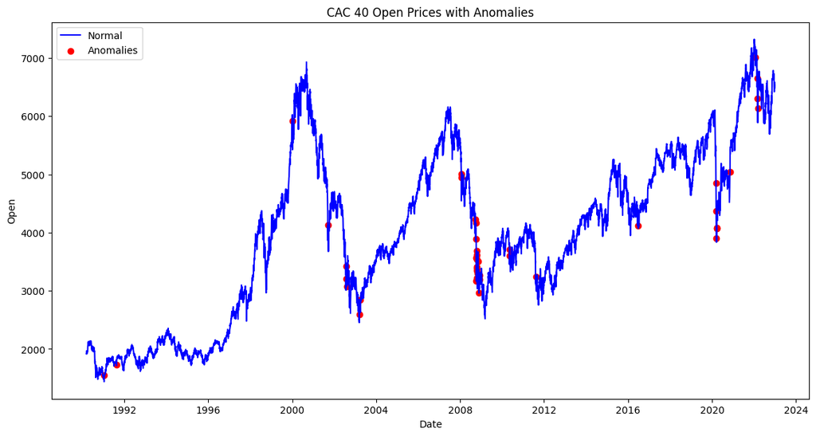

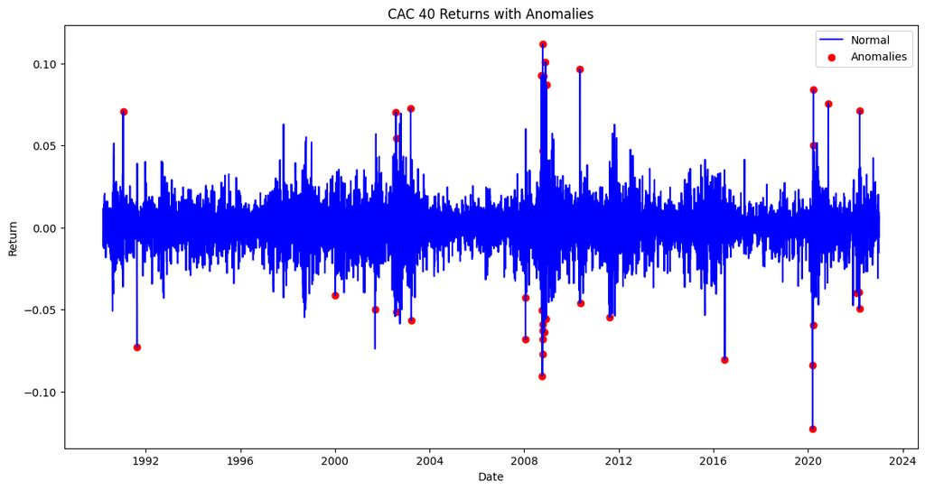

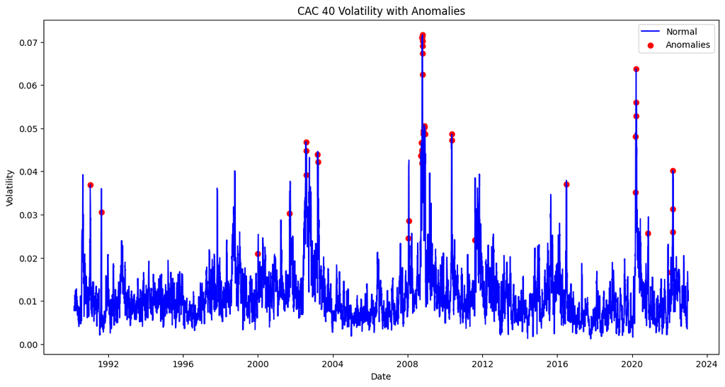

```python
import matplotlib.pyplot as plt

# Visualiser les anomalies détectées pour les prix d'ouverture
plt.figure(figsize=(14, 7))
plt.plot(fchi_data['Date'], fchi_data['Open'], color='blue', label='Normal')
plt.scatter(fchi_data[fchi_data['Anomaly'] == True]['Date'], fchi_data[fchi_data['Anomaly'] == True]['Open'], color='red', label='Anomalies')
plt.xlabel('Date')
plt.ylabel('Open')
plt.title('CAC 40 Open Prices with Anomalies')
plt.legend()
plt.show()

# Visualisation des anomalies pour les données de retour (Return)
plt.figure(figsize=(14, 7))
plt.plot(fchi_data['Date'], fchi_data['Return'], color='blue', label='Normal')
plt.scatter(fchi_data[fchi_data['Anomaly'] == True]['Date'], fchi_data[fchi_data['Anomaly'] == True]['Return'], color='red', label='Anomalies')
plt.xlabel('Date')
plt.ylabel('Return')
plt.title('CAC 40 Returns with Anomalies')
plt.legend()
plt.show()

# Visualisation des anomalies pour les données de volatilité (Volatility)
plt.figure(figsize=(14, 7))
plt.plot(fchi_data['Date'], fchi_data['Volatility'], color='blue', label='Normal')
plt.scatter(fchi_data[fchi_data['Anomaly'] == True]['Date'], fchi_data[fchi_data['Anomaly'] == True]['Volatility'], color='red', label='Anomalies')
plt.xlabel('Date')
plt.ylabel('Volatility')
plt.title('CAC 40 Volatility with Anomalies')
plt.legend()
plt.show()
```

Ce code permet de détecter des anomalies dans les données historiques de l'indice Dow Jones Industrial Average en utilisant un modèle d'autoencodeur. En normalisant les données et en comparant les erreurs de reconstruction aux valeurs prédéfinies, le code identifie les jours où le comportement du marché a été particulièrement atypique.

```python
import yfinance as yf
import pandas as pd
import numpy as np
from sklearn.preprocessing import StandardScaler

# Télécharger les données pour l'indice DJI (Dow Jones Industrial Average)
dji_data = yf.download("^DJI", start="1970-01-01", end="2022-12-31")

# Réinitialiser l'index et renommer la colonne index en 'Date'
dji_data.reset_index(inplace=True)
dji_data.rename(columns={'index': 'Date'}, inplace=True)

# Calculer la colonne Open-Close
dji_data['Open-Close'] = dji_data['Close'] - dji_data['Open']

# Calculer la colonne Return
dji_data['Return'] = (dji_data['Close'] / dji_data['Close'].shift(1) - 1)

# Calculer la colonne Volatility (écart-type sur une période de 7 jours)
dji_data['Volatility'] = dji_data['Return'].rolling(window=7).std()

# Supprimer les lignes contenant des valeurs manquantes dans les colonnes numériques
cols = ['Open', 'High', 'Low', 'Close', 'Adj Close', 'Open-Close', 'Return', 'Volatility']
dji_data.dropna(subset=cols, inplace=True)

# Normaliser les données
scaler = StandardScaler()
dji_data_scaled = scaler.fit_transform(dji_data[cols])

# Prédire les données
predictions = autoencoder.predict(dji_data_scaled.reshape(-1, len(cols), 1))

# Supprimer la dimension supplémentaire de predictions
predictions = predictions.squeeze()

# Calculer l'erreur de reconstruction
mse = np.mean(np.power(dji_data_scaled - predictions, 2), axis=1)

# Calculer le 99.5ème percentile
threshold = np.percentile(mse, 99.5)

# Identifier les anomalies
anomalies = mse > threshold

# Ajouter une colonne au DataFrame pour indiquer les anomalies
dji_data['Anomaly'] = anomalies

# Afficher les anomalies
print(f"Nombre d'anomalies détectées: {sum(anomalies)}")
print("Dates des anomalies détectées:")
print(dji_data[dji_data['Anomaly'] == True]['Date'])
```

```
[*********************100%%**********************]  1 of 1 completed
```

```
 93/244 ━━━━━━━━━━━━━━━━━━━━ 0s 1ms/step
```

```
244/244 ━━━━━━━━━━━━━━━━━━━━ 0s 1ms/step
Nombre d'anomalies détectées: 40
Dates des anomalies détectées:
1472   1997-10-27
2448   2001-09-17
4219   2008-09-29
4227   2008-10-09
4229   2008-10-13
4231   2008-10-15
4232   2008-10-16
4233   2008-10-17
4234   2008-10-20
4235   2008-10-21
4236   2008-10-22
4240   2008-10-28
```

[output cut: 29 more lines]

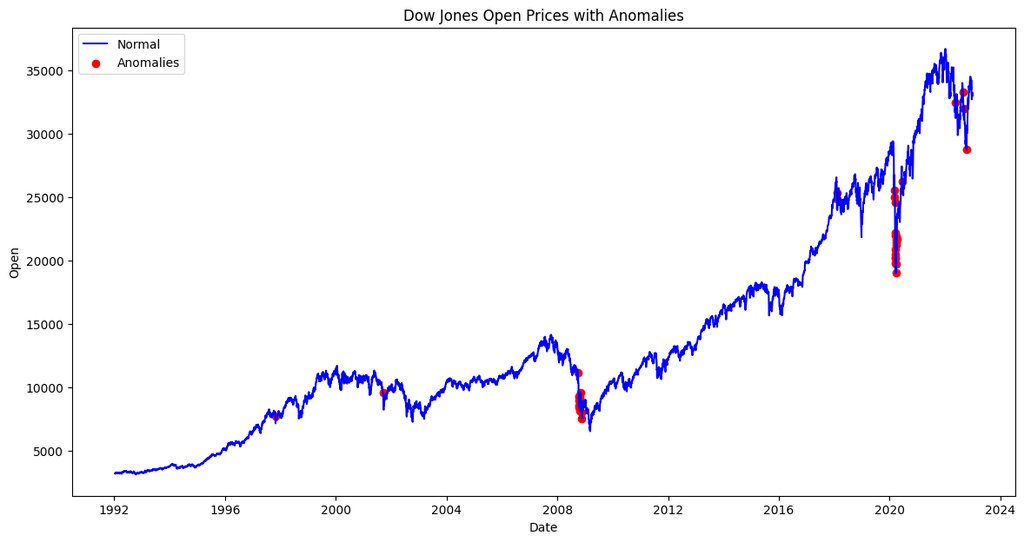

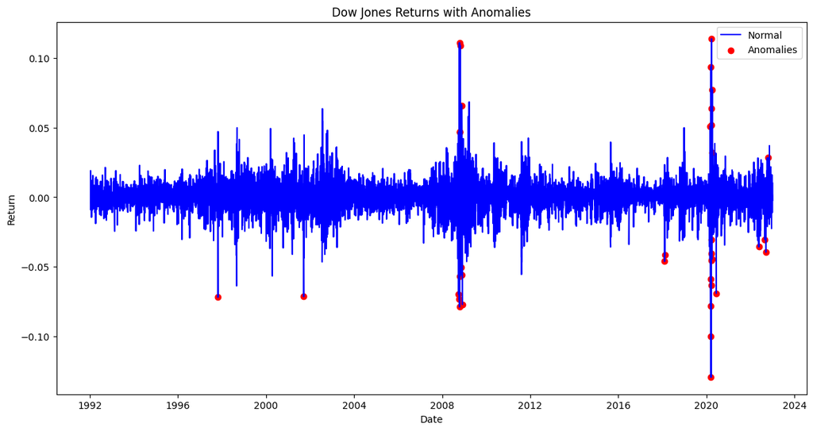

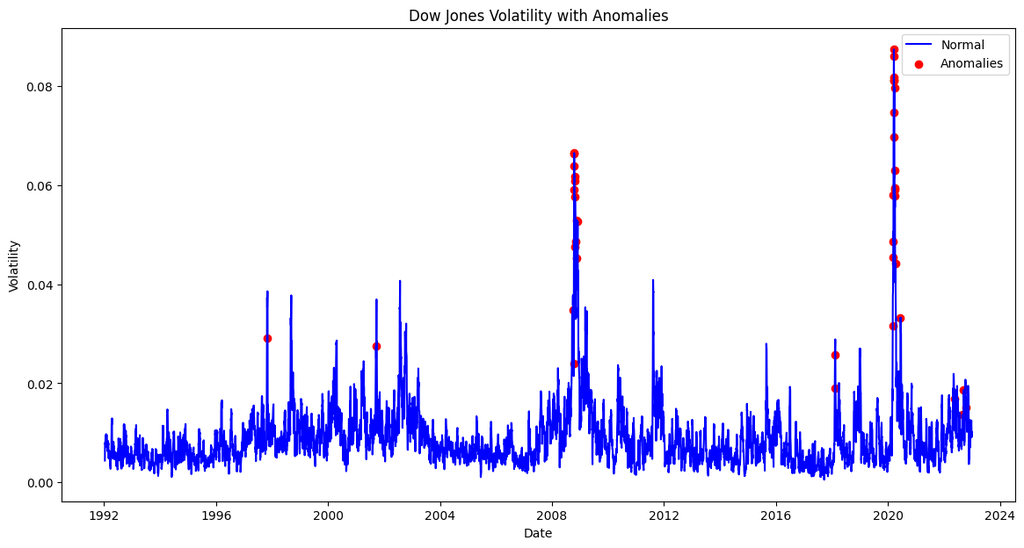

```python
import matplotlib.pyplot as plt

# Visualiser les anomalies détectées pour les prix d'ouverture
plt.figure(figsize=(14, 7))
plt.plot(dji_data['Date'], dji_data['Open'], color='blue', label='Normal')
plt.scatter(dji_data[dji_data['Anomaly'] == True]['Date'], dji_data[dji_data['Anomaly'] == True]['Open'], color='red', label='Anomalies')
plt.xlabel('Date')
plt.ylabel('Open')
plt.title('Dow Jones Open Prices with Anomalies')
plt.legend()
plt.show()

# Visualisation des anomalies pour les données de retour (Return)
plt.figure(figsize=(14, 7))
plt.plot(dji_data['Date'], dji_data['Return'], color='blue', label='Normal')
plt.scatter(dji_data[dji_data['Anomaly'] == True]['Date'], dji_data[dji_data['Anomaly'] == True]['Return'], color='red', label='Anomalies')
plt.xlabel('Date')
plt.ylabel('Return')
plt.title('Dow Jones Returns with Anomalies')
plt.legend()
plt.show()

# Visualisation des anomalies pour les données de volatilité (Volatility)
plt.figure(figsize=(14, 7))
plt.plot(dji_data['Date'], dji_data['Volatility'], color='blue', label='Normal')
plt.scatter(dji_data[dji_data['Anomaly'] == True]['Date'], dji_data[dji_data['Anomaly'] == True]['Volatility'], color='red', label='Anomalies')
plt.xlabel('Date')
plt.ylabel('Volatility')
plt.title('Dow Jones Volatility with Anomalies')
plt.legend()
plt.show()
```

Nous utilisons cette fois les données historiques de l'indice BSE Sensex afin d'enrichir notre étude par la diversification des analyses. Cela nous permet d'identifier des corrélations et des tendances globales, de valider la robustesse de notre modèle d'autoencodeur sur différents ensembles de données, et d'examiner les particularités spécifiques de divers marchés boursiers. En adoptant cette approche multi-indices, nous pouvons comparer les comportements anormaux entre différents marchés et comprendre l'impact global des événements économiques. Ainsi, nous obtenons une vue plus complète et approfondie des comportements anormaux dans les marchés financiers mondiaux. L'intégration des données historiques de l'indice BSE Sensex dans notre étude enrichit notre analyse par la diversification et permet d'identifier des corrélations et des tendances globales, de valider la robustesse de notre modèle sur différents ensembles de données, et d'examiner les particularités spécifiques de divers marchés boursiers. Cette approche multi-indices offre une vue plus complète et approfondie des comportements anormaux dans les marchés financiers mondiaux, contribuant ainsi à une meilleure compréhension et à des décisions d'investissement plus éclairées.

```python
import yfinance as yf
import pandas as pd
import numpy as np
from sklearn.preprocessing import StandardScaler

# Télécharger les données pour l'indice BSE Sensex
bse_data = yf.download("^BSESN", start="1970-01-01", end="2022-12-31")

# Réinitialiser l'index et renommer la colonne index en 'Date'
bse_data.reset_index(inplace=True)
bse_data.rename(columns={'index': 'Date'}, inplace=True)

# Calculer la colonne Open-Close
bse_data['Open-Close'] = bse_data['Close'] - bse_data['Open']

# Calculer la colonne Return
bse_data['Return'] = (bse_data['Close'] / bse_data['Open'] - 1)

# Calculer la colonne Volatility (écart-type sur une période de 7 jours)
bse_data['Volatility'] = bse_data['Return'].rolling(window=7).std()

# Supprimer les lignes contenant des valeurs manquantes dans les colonnes numériques
cols = ['Open', 'High', 'Low', 'Close', 'Adj Close', 'Open-Close', 'Return', 'Volatility']
bse_data.dropna(subset=cols, inplace=True)

# Normaliser les données
scaler = StandardScaler()
bse_data_scaled = scaler.fit_transform(bse_data[cols])

# Prédire les données
predictions = autoencoder.predict(bse_data_scaled.reshape(-1, len(cols), 1))

# Supprimer la dimension supplémentaire de predictions
predictions = predictions.squeeze()

# Calculer l'erreur de reconstruction
mse = np.mean(np.power(bse_data_scaled - predictions, 2), axis=1)

# Calculer le 99.5ème percentile
threshold = np.percentile(mse, 99.5)

# Identifier les anomalies
anomalies = mse > threshold

# Ajouter une colonne au DataFrame pour indiquer les anomalies
bse_data['Anomaly'] = anomalies

# Afficher les anomalies
print(f"Nombre d'anomalies détectées: {sum(anomalies)}")
print("Dates des anomalies détectées:")
print(bse_data[bse_data['Anomaly'] == True]['Date'])
```

```
[*********************100%%**********************]  1 of 1 completed
```

```
 93/197 ━━━━━━━━━━━━━━━━━━━━ 0s 1ms/step
```

```
197/197 ━━━━━━━━━━━━━━━━━━━━ 0s 1ms/step
Nombre d'anomalies détectées: 32
Dates des anomalies détectées:
693    2000-05-02
697    2000-05-08
1699   2004-05-17
1700   2004-05-18
1701   2004-05-19
1702   2004-05-20
1703   2004-05-21
1704   2004-05-24
2616   2008-01-21
2799   2008-10-17
2804   2008-10-24
2810   2008-11-05
```

[output cut: 21 more lines]

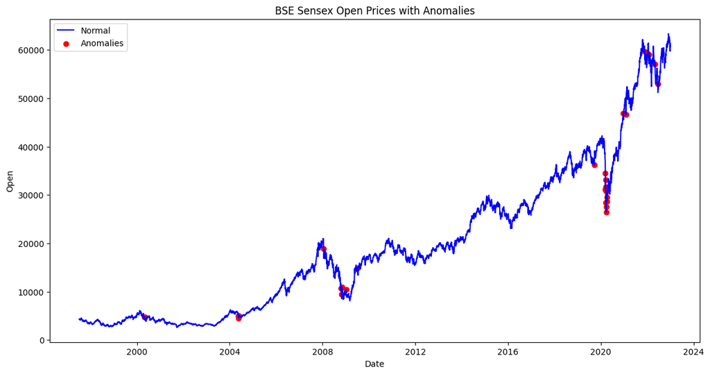

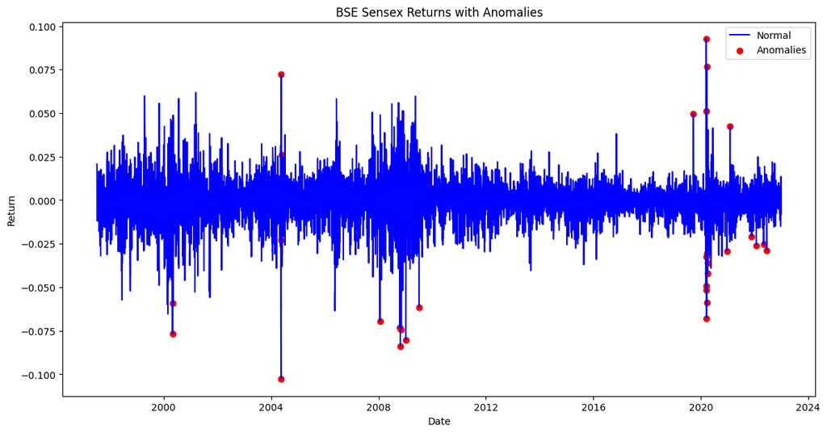

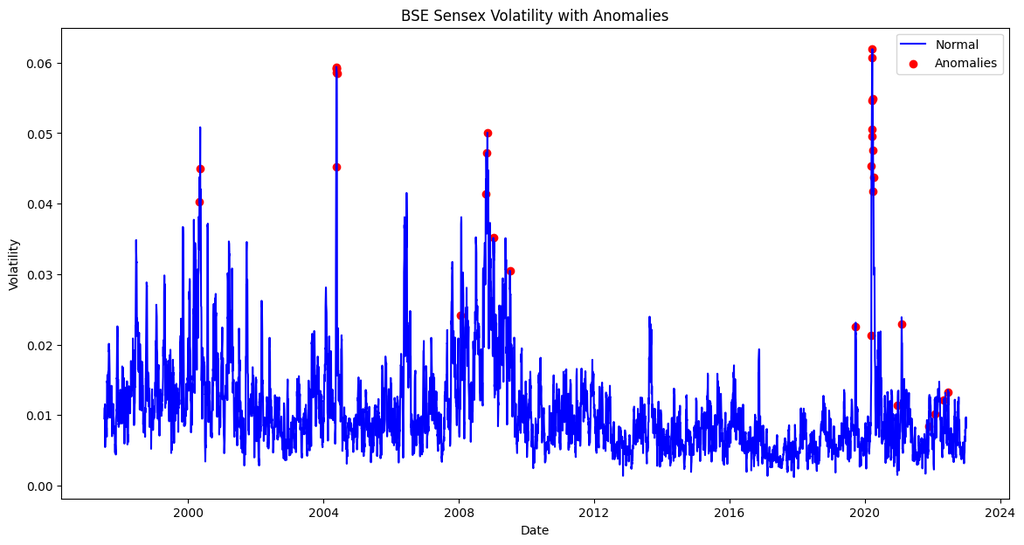

```python
import matplotlib.pyplot as plt

# Visualiser les anomalies détectées pour les prix d'ouverture
plt.figure(figsize=(14, 7))
plt.plot(bse_data['Date'], bse_data['Open'], color='blue', label='Normal')
plt.scatter(bse_data[bse_data['Anomaly'] == True]['Date'], bse_data[bse_data['Anomaly'] == True]['Open'], color='red', label='Anomalies')
plt.xlabel('Date')
plt.ylabel('Open')
plt.title('BSE Sensex Open Prices with Anomalies')
plt.legend()
plt.show()

# Visualisation des anomalies pour les données de retour (Return)
plt.figure(figsize=(14, 7))
plt.plot(bse_data['Date'], bse_data['Return'], color='blue', label='Normal')
plt.scatter(bse_data[bse_data['Anomaly'] == True]['Date'], bse_data[bse_data['Anomaly'] == True]['Return'], color='red', label='Anomalies')
plt.xlabel('Date')
plt.ylabel('Return')
plt.title('BSE Sensex Returns with Anomalies')
plt.legend()
plt.show()

# Visualisation des anomalies pour les données de volatilité (Volatility)
plt.figure(figsize=(14, 7))
plt.plot(bse_data['Date'], bse_data['Volatility'], color='blue', label='Normal')
plt.scatter(bse_data[bse_data['Anomaly'] == True]['Date'], bse_data[bse_data['Anomaly'] == True]['Volatility'], color='red', label='Anomalies')
plt.xlabel('Date')
plt.ylabel('Volatility')
plt.title('BSE Sensex Volatility with Anomalies')
plt.legend()
plt.show()
```

```python
# Charger le scaler et l'autoencodeur
from sklearn.preprocessing import StandardScaler
from tensorflow.keras.models import load_model

scaler = StandardScaler()  # Assurez-vous de spécifier le bon chemin

def preprocess_example_row(example_row, cols):
    # Diviser la ligne en valeurs individuelles
    example_values = example_row.split(';')

    # Créer un DataFrame à partir de la ligne
    example_df = pd.DataFrame({'Date': [example_values[0]],
                               'Open': [float(example_values[1].replace(',', '.'))],
                               'High': [float(example_values[2].replace(',', '.'))],
                               'Low': [float(example_values[3].replace(',', '.'))],
                               'Close': [float(example_values[4].replace(',', '.'))],
                               'Adj Close': [float(example_values[5].replace(',', '.'))],
                               'Open-Close': [float(example_values[6].replace(',', '.'))],
                               'Return': [float(example_values[7].replace(',', '.'))],
                               'Volatility': [float(example_values[8].replace(',', '.'))]})

    # Convertir la colonne de date en datetime
    example_df['Date'] = pd.to_datetime(example_df['Date'], dayfirst=True)

    return example_df

def estimate_anomaly_probability(example_df, scaler, autoencoder, threshold):
    # Normaliser les données
    scaled_example = scaler.transform(example_df[cols].values)

    # Prédire la reconstruction de la ligne d'exemple
    reconstructed_example = autoencoder.predict(scaled_example.reshape(1, len(cols), 1))

    # Calculer l'erreur de reconstruction pour la ligne d'exemple
    example_mse = np.mean(np.square(scaled_example.reshape(1, len(cols), 1) - reconstructed_example))

    # Calculer le 99.9ème percentile
    threshold = np.percentile(mse, 99.9)

    # Estimer la probabilité que la ligne soit une anomalie
    example_anomaly_probability = np.clip(example_mse / threshold, 0, 1)

    return example_anomaly_probability

# Exemple de ligne saisie par l'utilisateur
example_row = "22/06/2020;25865,08008;26059,81055;25667,67969;26024,96094;26024,96094;-159,88086;0,005933179;0,028231554"

# Prétraiter la ligne d'exemple
example_df = preprocess_example_row(example_row, cols)

# Charger le scaler à partir des données d'entraînement
scaler.fit(features)

# Estimer la probabilité que la ligne soit une anomalie
anomaly_probability = estimate_anomaly_probability(example_df, scaler, autoencoder, threshold)

print("Probabilité d'anomalie pour la ligne d'exemple :", anomaly_probability)
```

```
1/1 ━━━━━━━━━━━━━━━━━━━━ 0s 21ms/step
Probabilité d'anomalie pour la ligne d'exemple : 0.16033978345914746
```

```python
import yfinance as yf
import schedule
import time

# Définir la fonction pour télécharger les données des 10 derniers jours
def get_latest_index_data(index_symbol, days=10):
    try:
        # Télécharger les données des 10 derniers jours
        end_date = pd.to_datetime("today").strftime('%Y-%m-%d')
        start_date = (pd.to_datetime("today") - pd.Timedelta(days=days)).strftime('%Y-%m-%d')
        index_data = yf.download(index_symbol, start=start_date, end=end_date)
        index_data.reset_index(inplace=True)

        # Calculer Open-Close
        index_data['Open-Close'] = index_data['Close'] - index_data['Open']

        # Calculer Return
        index_data['Return'] = index_data['Close'].pct_change()

        # Calculer Volatility (Rolling standard deviation of returns)
        index_data['Volatility'] = index_data['Return'].rolling(window=7).std()

        # Calculer Volatility sur une fenêtre de 6 jours pour les valeurs nulles
        index_data['Volatility'] = index_data['Volatility'].fillna(index_data['Return'].rolling(window=6).std())

        # Extraire la dernière ligne disponible (ou la première si aucune n'est disponible)
        last_available_row = index_data.iloc[-1:] if not index_data.empty else index_data.iloc[:1]

        # Redimensionner le DataFrame pour avoir une seule ligne (1, 10)
        index_data = last_available_row
        return index_data

    except Exception as e:
        print(f"Erreur lors du téléchargement des données pour {index_symbol}: {e}")
        return None

def check_anomaly_for_indices(indices):
    # Dictionnaire contenant des explications sur chaque indice
    index_descriptions = {
        '^FCHI': "CAC 40 - Indice boursier français composé des 40 entreprises les plus importantes cotées sur Euronext Paris.",
        '^DJI': "Dow Jones Industrial Average - Indice boursier américain composé de 30 grandes entreprises américaines.",
        '^GSPC': "S&P 500 - Indice boursier américain composé de 500 grandes entreprises américaines.",
        '^IXIC': "NASDAQ Composite - Indice boursier américain composé de plus de 2500 actions cotées sur le NASDAQ.",
        '^GDAXI': "DAX - Indice boursier allemand composé de 30 grandes entreprises allemandes.",
        '^N225': "Nikkei 225 - Indice boursier japonais composé de 225 entreprises cotées à la Bourse de Tokyo.",
        '^HSI': "Hang Seng Index - Principal indice boursier de la Bourse de Hong Kong, composé de 50 entreprises.",
        '^FTSE': "FTSE 100 - Indice boursier britannique composé des 100 plus grandes entreprises cotées à la Bourse de Londres.",
        '^BSESN': "BSE Sensex - Indice boursier de référence de la Bourse de Bombay, composé de 30 entreprises.",
        '^AORD': "S&P/ASX 200 - Indice boursier australien composé des 200 plus grandes entreprises cotées sur la Bourse australienne."
    }

    for index_symbol in indices:
        print(f"Analyse de l'indice {index_symbol}:")
        example_df = get_latest_index_data(index_symbol)
        if example_df is not None and not example_df.empty:
            anomaly_probability = estimate_anomaly_probability(example_df, scaler, autoencoder, threshold)
            print("Probabilité d'anomalie pour la ligne", anomaly_probability)
            # Extraire les données de l'exemple DataFrame
            example_row = example_df.iloc[-1]
            # Convertir l'index en objet de date/heure
            example_date = pd.to_datetime(example_row.name)
            # Imprimer les données de manière lisible
            print("Données :")
            print(f"Date: {example_row['Date'].strftime('%d/%m/%Y')}, Open: {example_row['Open']}, High: {example_row['High']}, Low: {example_row['Low']}, Close: {example_row['Close']}, Adj Close: {example_row['Adj Close']}, Open-Close: {example_row['Open-Close']}, Return: {example_row['Return']}, Volatility: {example_row['Volatility']}")
            print("Description de l'indice:", index_descriptions.get(index_symbol, "Description non disponible."))
        else:
            print("Aucune donnée disponible pour cette heure.")
        print()


# Liste des indices à tester
indices_to_test = ['^FCHI', '^DJI', '^GSPC', '^IXIC', '^GDAXI', '^N225', '^HSI', '^FTSE', '^BSESN', '^AORD']

# Appeler la fonction pour vérifier les anomalies pour chaque indice
check_anomaly_for_indices(indices_to_test)
```

```
Analyse de l'indice ^FCHI:
```

```
[*********************100%%**********************]  1 of 1 completed
```

```
1/1 ━━━━━━━━━━━━━━━━━━━━ 0s 17ms/step
```

```
[*********************100%%**********************]  1 of 1 completed
```

```
Probabilité d'anomalie pour la ligne 0.00020805580804581186
Données :
Date: 31/05/2024, Open: 7972.5498046875, High: 7996.89013671875, Low: 7960.169921875, Close: 7992.8701171875, Adj Close: 7992.8701171875, Open-Close: 20.3203125, Return: 0.001799878922799758, Volatility: 0.007665555646268915
Description de l'indice: CAC 40 - Indice boursier français composé des 40 entreprises les plus importantes cotées sur Euronext Paris.

Analyse de l'indice ^DJI:
1/1 ━━━━━━━━━━━━━━━━━━━━ 0s 19ms/step
```

```
[*********************100%%**********************]  1 of 1 completed
```

```
Probabilité d'anomalie pour la ligne 0.615986685529583
Données :
Date: 31/05/2024, Open: 38140.26171875, High: 38719.4296875, Low: 38092.26953125, Close: 38686.3203125, Adj Close: 38686.3203125, Open-Close: 546.05859375, Return: 0.015083115026752747, Volatility: 0.009793919867890938
Description de l'indice: Dow Jones Industrial Average - Indice boursier américain composé de 30 grandes entreprises américaines.

Analyse de l'indice ^GSPC:
1/1 ━━━━━━━━━━━━━━━━━━━━ 0s 22ms/step
```

```
Probabilité d'anomalie pour la ligne 0.008011355071172703
Données :
Date: 31/05/2024, Open: 5243.2099609375, High: 5280.330078125, Low: 5191.68017578125, Close: 5277.509765625, Adj Close: 5277.509765625, Open-Close: 34.2998046875, Return: 0.00802787620486467, Volatility: 0.006529484162261382
Description de l'indice: S&P 500 - Indice boursier américain composé de 500 grandes entreprises américaines.

Analyse de l'indice ^IXIC:
```

```
[*********************100%%**********************]  1 of 1 completed
```

```
1/1 ━━━━━━━━━━━━━━━━━━━━ 0s 19ms/step
```

```
[*********************100%%**********************]  1 of 1 completed
```

```
Probabilité d'anomalie pour la ligne 0.0015642530805591206
Données :
Date: 31/05/2024, Open: 16771.900390625, High: 16789.26953125, Low: 16445.5390625, Close: 16735.01953125, Adj Close: 16735.01953125, Open-Close: -36.880859375, Return: -0.00012311268544940024, Volatility: 0.0073244105626784845
Description de l'indice: NASDAQ Composite - Indice boursier américain composé de plus de 2500 actions cotées sur le NASDAQ.

Analyse de l'indice ^GDAXI:
1/1 ━━━━━━━━━━━━━━━━━━━━ 0s 17ms/step
```

```
Probabilité d'anomalie pour la ligne 0.006471430619214843
Données :
Date: 31/05/2024, Open: 18495.220703125, High: 18542.26953125, Low: 18426.720703125, Close: 18497.939453125, Adj Close: 18497.939453125, Open-Close: 2.71875, Return: 6.219407169072433e-05, Volatility: 0.005066234302645768
Description de l'indice: DAX - Indice boursier allemand composé de 30 grandes entreprises allemandes.

Analyse de l'indice ^N225:
```

```
[*********************100%%**********************]  1 of 1 completed
```

```
1/1 ━━━━━━━━━━━━━━━━━━━━ 0s 17ms/step
```

```
1/1 ━━━━━━━━━━━━━━━━━━━━ 0s 18ms/step
Probabilité d'anomalie pour la ligne 0.4666220724486679
Données :
Date: 31/05/2024, Open: 38173.21875, High: 38526.9296875, Low: 38087.609375, Close: 38487.8984375, Adj Close: 38487.8984375, Open-Close: 314.6796875, Return: 0.011398750772054989, Volatility: 0.010780184858126339
Description de l'indice: Nikkei 225 - Indice boursier japonais composé de 225 entreprises cotées à la Bourse de Tokyo.

Analyse de l'indice ^HSI:
```

```
[*********************100%%**********************]  1 of 1 completed
```

```
1/1 ━━━━━━━━━━━━━━━━━━━━ 0s 19ms/step
```

```
[*********************100%%**********************]  1 of 1 completed
```

```
Probabilité d'anomalie pour la ligne 0.1165975173439789
Données :
Date: 31/05/2024, Open: 18409.619140625, High: 18551.1796875, Low: 18077.390625, Close: 18079.609375, Adj Close: 18079.609375, Open-Close: -330.009765625, Return: -0.008259929416103096, Volatility: 0.01077187258831839
Description de l'indice: Hang Seng Index - Principal indice boursier de la Bourse de Hong Kong, composé de 50 entreprises.

Analyse de l'indice ^FTSE:
```

```
1/1 ━━━━━━━━━━━━━━━━━━━━ 0s 19ms/step
```

```
[*********************100%%**********************]  1 of 1 completed
```

```
Probabilité d'anomalie pour la ligne 0.0020360960889552553
Données :
Date: 31/05/2024, Open: 8231.099609375, High: 8289.2001953125, Low: 8231.099609375, Close: 8275.400390625, Adj Close: 8275.400390625, Open-Close: 44.30078125, Return: 0.0053821218734302345, Volatility: 0.005860561623665747
Description de l'indice: FTSE 100 - Indice boursier britannique composé des 100 plus grandes entreprises cotées à la Bourse de Londres.

Analyse de l'indice ^BSESN:
```

```
1/1 ━━━━━━━━━━━━━━━━━━━━ 0s 19ms/step
Probabilité d'anomalie pour la ligne 1.0
Données :
Date: 31/05/2024, Open: 74208.53125, High: 74478.890625, Low: 73765.1484375, Close: 73961.3125, Adj Close: 73961.3125, Open-Close: -247.21875, Return: 0.0010247048937668257, Volatility: 0.008323614762497085
Description de l'indice: BSE Sensex - Indice boursier de référence de la Bourse de Bombay, composé de 30 entreprises.

Analyse de l'indice ^AORD:
```

```
[*********************100%%**********************]  1 of 1 completed
```

```
1/1 ━━━━━━━━━━━━━━━━━━━━ 0s 19ms/step
Probabilité d'anomalie pour la ligne 4.766053922735929e-05
Données :
Date: 31/05/2024, Open: 7895.89990234375, High: 7970.7998046875, Low: 7895.89990234375, Close: 7970.7998046875, Adj Close: 7970.7998046875, Open-Close: 74.89990234375, Return: 0.009485923488153247, Volatility: 0.008277043337793303
Description de l'indice: S&P/ASX 200 - Indice boursier australien composé des 200 plus grandes entreprises cotées sur la Bourse australienne.
```